# Importaciones

### Año que mas importaciones hubo de gasolina Superior

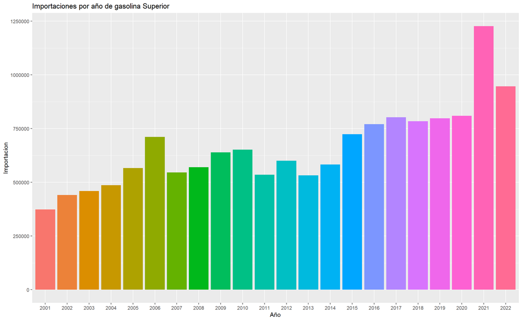

```r
chart_superior<-ggplot(importacion, aes(x = format(importacion$Fecha, format='%Y'), y = importacion$`Gasolina superior`, fill =format(importacion$Fecha, format='%Y') )) +
  geom_bar(stat = "identity",position=position_dodge())+labs(title="Importaciones por año de gasolina Superior", y="Importacion" , x='Año')+
  theme(legend.position="none")
#2021 Fue el año con mas importaciones
#Vemos a detalle que paso en ese año


mes_2021<-subset(importacion,Fecha<'2022-01-01' & Fecha>'2020-12-31')


chart_superior_mes<-ggplot(mes_2021, aes(x = format(mes_2021$Fecha, format='%m'), y = mes_2021$`Gasolina superior`, fill =format(mes_2021$Fecha, format='%m') )) +
  geom_bar(stat = "identity",position=position_dodge())+labs(title="Importaciones por mes de gasolina Superior en el año 2021", y="Importacion" , x='Mes')+
  theme(legend.position="none")
chart_superior
```

Como se observa en la grafica anterior el año con mayor importacion fue 2021, donde en la siguiente grafica veremos a mas detalle que ocurrio durante los meses

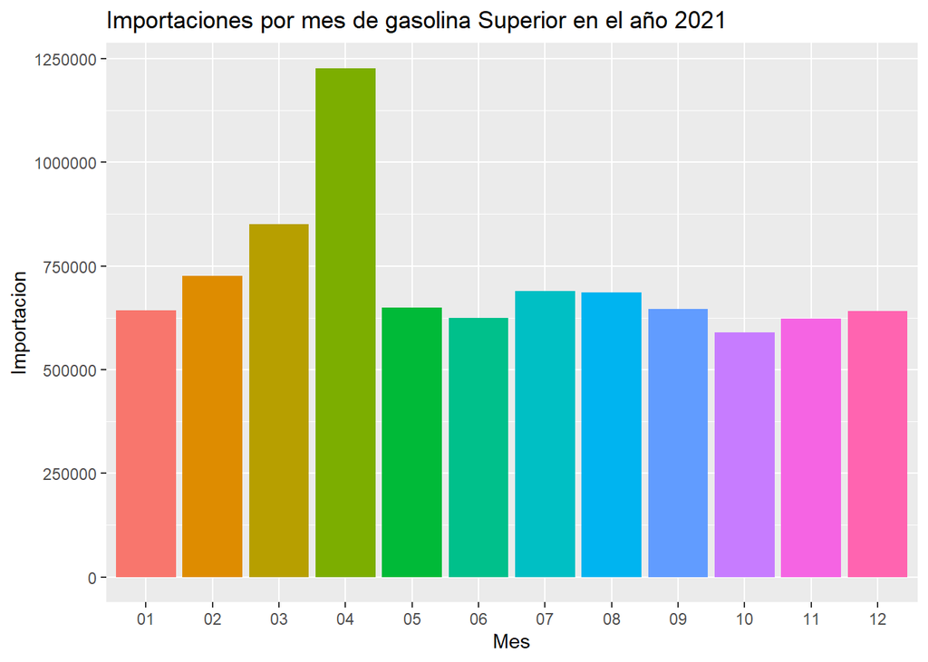

```r
chart_superior_mes
```

Como se logra observar el pico de importaciones de ese año es el mes de abril, un año despues del comienzo de la pandemia, cuando las regulaciones habian disminuido y las personas podian salir con mayor libertad.